# ALY6050_Module 2 Project_Shamim Sherafati

2023-03-09

# part 1-1

### Perform a simulation of 10,000 benefit-cost ratios for Dam #1 project and 10,000 such simulations for Dam #2 project. Note that the two simulations should be independent of each other. Let these two ratios be denoted by a1 and a2 for the dams 1 and 2 projects respectively.

```r
# load the package
library(extraDistr)

# Define benefits and costs for Dam 1
B1 <- c(1.1, 2, 2.8)
B2 <- c(8, 12, 14.9)
B3 <- c(1.4, 1.4, 2.2)
B4 <- c(6.5, 9.8, 14.6)
B5 <- c(1.7, 2.4, 3.6)
B6 <- c(0, 1.6, 2.4)
C1 <- c(13.2, 14.2, 19.1)
C2 <- c(3.5, 4.9, 7.4)

# Define benefits and costs for Dam 2
B1_d2 <- c(2.1, 3, 4.8)
B2_d2 <- c(8.7, 12.2, 13.6)
B3_d2 <- c(2.3, 3, 3)
B4_d2 <- c(5.9, 8.7, 15)
B5_d2 <- c(0, 3.4, 3.4)
B6_d2 <- c(0, 1.2, 1.8)
C1_d2 <- c(12.8, 15.8, 20.1)
C2_d2 <- c(3.8, 5.7, 8)

# Perform simulation for Dam 1
d1_benefit_params = list(B1, B2, B3, B4, B5, B6)
d1_cost_params = list(C1, C2)
a1 <- c()
benefits_dam1 <- c()
costs_dam1 <- c()


for (i in 1:1e4) {
  benefits <- sapply(d1_benefit_params, function(params) {rtriangle(1e4, params[1], params[3], params[2])})
  costs <- sapply(d1_cost_params, function(params) {rtriangle(1e4, params[1], params[3], params[2])})
  ratio <- sum(benefits) / sum(costs)
  benefits_dam1 <- c(benefits_dam1, sum(benefits))
  costs_dam1 <- c(costs_dam1, sum(costs))
  a1 <- c(a1, ratio)
}
# Convert a1 to data frame format
a1_df <- as.data.frame(a1)
# Print the data frame
print(a1_df)
```

```
##            a1
## 1    1.419317
## 2    1.420260
## 3    1.418602
## 4    1.419758
## 5    1.416334
## 6    1.418492
## 7    1.418785
## 8    1.417669
## 9    1.417424
## 10   1.417811
## 11   1.422310
## 12   1.419057
## 13   1.420185
## 14   1.419583
```

[output cut: 987 more lines]

```r
# Perform simulation for Dam 2
d2_benefit_params = list(B1_d2, B2_d2, B3_d2, B4_d2, B5_d2, B6_d2)
d2_cost_params = list(C1_d2, C2_d2)
a2 <- c()
benefits_dam2 <- c()
costs_dam2 <- c()

for (i in 1:1e4) {
  benefits2 <- sapply(d2_benefit_params, function(params) {rtriangle(1e4, params[1], params[3], params[2])})
  costs2 <- sapply(d2_cost_params, function(params) {rtriangle(1e4, params[1], params[3], params[2])})
  ratio2 <- sum(benefits2) / sum(costs2)
  benefits_dam2 <- c(benefits_dam2, sum(benefits2))
  costs_dam2 <- c(costs_dam2, sum(costs2))
  a2 <- c(a2, ratio2)
}

# Convert a2 to data frame format
a2_df <- as.data.frame(a2)
# Print the data frame
print(a2_df)
```

```
##            a2
## 1    1.390653
## 2    1.391306
## 3    1.392078
## 4    1.390990
## 5    1.392139
## 6    1.389604
## 7    1.391367
## 8    1.390367
## 9    1.392295
## 10   1.391044
## 11   1.391017
## 12   1.389081
## 13   1.390351
## 14   1.390026
```

[output cut: 987 more lines]

```r
# get the summary for a1 and a2 to get information about the range of the simulation
summary(a1)
```

```
##    Min. 1st Qu.  Median    Mean 3rd Qu.    Max.
##   1.412   1.418   1.419   1.419   1.420   1.425
```

```r
summary(a2)
```

```
##    Min. 1st Qu.  Median    Mean 3rd Qu.    Max.
##   1.385   1.390   1.391   1.391   1.392   1.397
```

# Part 1-2

### Construct both a tabular and a graphical frequency distribution for a1 and a2 separately (a tabular and a graphical distribution for a2, and a tabular and a graphical distribution for a2- a total of 4 distributions). In your report, include only the graphical distributions and comment on the shape of each distribution.

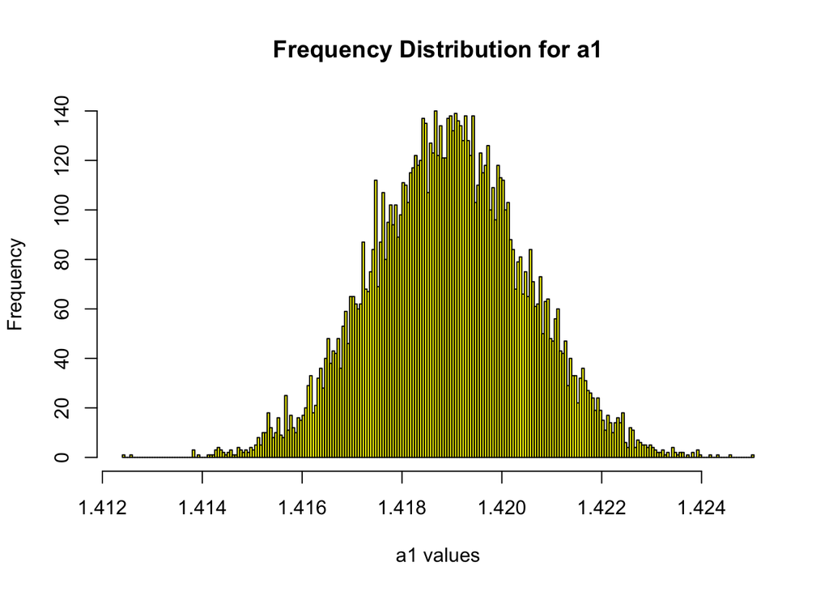

```r
# Create graphical frequency distribution plot for Dam 1:
# Frequency distribution for a1
hist(a1, breaks = 200,col = "yellow",  main = "Frequency Distribution for a1", xlab = "a1 values", ylab = "Frequency")
```

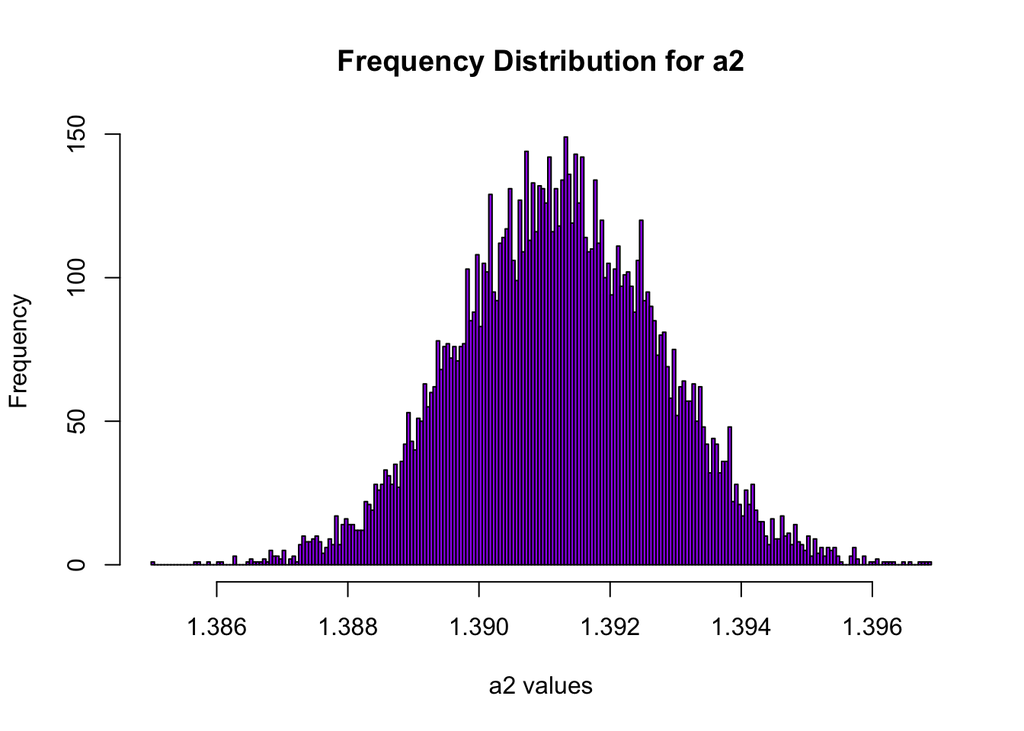

```r
# Create graphical frequency distribution plot for Dam 2:
# Frequency distribution for a2
hist(a2, breaks = 200,col = "purple",  main = "Frequency Distribution for a2", xlab = "a2 values", ylab = "Frequency")
```

```r
# Frequency distribution for a1
freq_table_a1 <- table(a1)

# Convert freq_table_a1 to data frame format
freq_table_a1 <- as.data.frame(freq_table_a1)
# Print the data frame
print(freq_table_a1)
```

```
##                   a1 Freq
## 1   1.41243469843068    1
## 2   1.41258180216458    1
## 3   1.41380619833446    1
## 4   1.41381963752162    1
## 5   1.41383753301797    1
## 6   1.41391872243807    1
## 7   1.41411386952802    1
## 8   1.41418961213893    1
## 9   1.41420159312134    1
## 10  1.41425492710319    1
## 11   1.4142641750371    1
## 12   1.4142779043826    1
## 13  1.41431198940686    1
## 14  1.41432524631733    1
```

[output cut: 487 more lines]

```r
# Frequency distribution for a2
freq_table_a2 <- table(a2)

# Convert freq_table_a2 to data frame format
freq_table_a2 <- as.data.frame(freq_table_a2)
# Print the data frame
print(freq_table_a2)
```

```
##                   a2 Freq
## 1   1.38502543604637    1
## 2   1.38569280440477    1
## 3   1.38570116127817    1
## 4   1.38587243535425    1
## 5   1.38601148987578    1
## 6    1.3860694594845    1
## 7   1.38625001789659    1
## 8   1.38627199130449    1
## 9   1.38628831878802    1
## 10   1.3864578090697    1
## 11  1.38652090276146    1
## 12  1.38654382140996    1
## 13  1.38657010542435    1
## 14   1.3866142106192    1
```

[output cut: 487 more lines]

# part 1-3

### For each of the two dam projects, perform the necessary calculations in order to complete the following table. Excel users should create the table in Excel with all cells being occupied by the appropriate formulas, and R users should display the table as a “data frame”. Remember to create two such tables – one table for Dam #1 and another table for Dam #2. Include both tables in your report.

## calculations for Dam1:

```r
d1_benefit_params = list(B1, B2, B3, B4, B5, B6)
d1_cost_params = list(C1, C2)
ratios_dam1 <- c()
benefits_dam1 <- c()
costs_dam1 <- c()

for (i in 1:1e4) {
  benefits <- sapply(d1_benefit_params, function(params) {rtriangle(1, params[1], params[3], params[2])})
  costs <- sapply(d1_cost_params, function(params) {rtriangle(1, params[1], params[3], params[2])})
  ratio <- sum(benefits) / sum(costs)
  benefits_dam1 <- c(benefits_dam1, sum(benefits))
  costs_dam1 <- c(costs_dam1, sum(costs))
  ratios_dam1 <- c(ratios_dam1, ratio)
}

mean(benefits_dam1)
```

```
## [1] 29.48537
```

```r
mean(costs_dam1)
```

```
## [1] 20.76958
```

```r
# Dam1
B1 <- c(1.1, 2, 2.8)
B2 <- c(8, 12, 14.9)
B3 <- c(1.4, 1.4, 2.2)
B4 <- c(6.5, 9.8, 14.6)
B5 <- c(1.7, 2.4, 3.6)
B6 <- c(0, 1.6, 2.4)
C1 <- c(13.2, 14.2, 19.1)
C2 <- c(3.5, 4.9, 7.4)

d1_benefit_params = list(B1, B2, B3, B4, B5, B6)
d1_cost_params = list(C1, C2)
ratios_dam1 <- c()
benefits_dam1 <- c()
costs_dam1 <- c()

for (i in 1:1e4) {
  benefits <- sapply(d1_benefit_params, function(params) {rtriangle(1, params[1], params[3], params[2])})
  costs <- sapply(d1_cost_params, function(params) {rtriangle(1, params[1], params[3], params[2])})
  ratio <- sum(benefits) / sum(costs)
  benefits_dam1 <- c(benefits_dam1, sum(benefits))
  costs_dam1 <- c(costs_dam1, sum(costs))
  ratios_dam1 <- c(ratios_dam1, ratio)
}

# Observed:

# Total Observed Benefits for Dam1
Obs_Benefit_D1 = sum(B1) + sum(B2) + sum(B3) + sum(B4) + sum(B5) + sum(B6)
Obs_Benefit_D1 = mean(benefits_dam1)
# Total Observed Cost for Dam1
Obs_Cost_D1 = sum(C1) + sum(C2)
Obs_Cost_D1 = mean(costs_dam1)

# Mean of the Total Observed Benefits for Dam1
mean_Obs_Benefit_D1 = mean(benefits_dam1)
## Standard Deviation of the Total Observed Benefits for Dam1
SD_Obs_Benefit_D1 = sd(benefits_dam1)

# Mean of the Total Observed Cost for Dam1
mean_Obs_Cost_D1 = mean(costs_dam1)
## Standarad Deviation of the Total Observed Cost for Dam1
SD_Obs_Cost_D1 = sd (costs_dam1)

#Mean of Observed Benefit-Cost Ratio for Dam1
mean_Obs_Ratio = mean(ratios_dam1)
#SD of Observed Benefit-Cost Ratio for Dam1
SD_Obs_Ratio = sd (ratios_dam1)


# Theoretical:

# Total Theoretical Benefits for Dam1
Theo_Benefit_D1 = mean(B1) + mean(B2) + mean(B3) + mean(B4) + mean(B5) + mean(B6)
# Total Theoretical Cost for Dam1
Theo_Cost_D1 = mean(C1) + mean(C2)

# Mean of the Total Theoretical Benefits for Dam1
mean_Theo_Benefit_D1 = sum(mean(B1), mean(B2), mean(B3), mean(B4), mean(B5), mean(B6))
## Standard Deviation of the Total Theoretical Benefits for Dam1
SD_Theo_Benefit_D1 <- sd(c(sd(B1), sd(B2), sd(B3), sd(B4), sd(B5), sd(B6)))

# Mean of the Total Theoretical Cost for Dam1
mean_Theo_Cost_D1 = sum( mean(C1) , mean(C2))
## Standarad Deviation of the Total Theoretical Cost for Dam1
SD_Theo_Cost_D1 <- sd(c(sd(C1), sd(C2)))



# Print results
cat("The Mean of the Total Observed Benefits for Dam1 ", mean_Obs_Benefit_D1, "\n")
```

```
## The Mean of the Total Observed Benefits for Dam1  29.46588
```

```r
cat("The Standarad Deviation of the Total Observed Benefits for Dam1  is", SD_Obs_Benefit_D1 , "\n")
```

```
## The Standarad Deviation of the Total Observed Benefits for Dam1  is 2.315988
```

```r
cat("The Mean of the Total Observed Cost for Dam1  is", mean_Obs_Cost_D1, "\n")
```

```
## The Mean of the Total Observed Cost for Dam1  is 20.76617
```

```r
cat("The Standarad Deviation of the Total Observed Cost for Dam1  is", SD_Obs_Cost_D1, "\n")
```

```
## The Standarad Deviation of the Total Observed Cost for Dam1  is 1.52375
```

```r
cat("The Mean of the Total Theoretical Benefits for Dam1 ", mean_Theo_Benefit_D1, "\n")
```

```
## The Mean of the Total Theoretical Benefits for Dam1  29.46667
```

```r
cat("The Standarad Deviation of the Total Theoretical Benefits for Dam1  is", SD_Theo_Benefit_D1 , "\n")
```

```
## The Standarad Deviation of the Total Theoretical Benefits for Dam1  is 1.527022
```

```r
cat("The Mean of the Total Theoretical Cost for Dam1  is", mean_Theo_Cost_D1, "\n")
```

```
## The Mean of the Total Theoretical Cost for Dam1  is 20.76667
```

```r
cat("The Standarad Deviation of the Total Theoretical Cost for Dam1  is", SD_Theo_Cost_D1, "\n")
```

```
## The Standarad Deviation of the Total Theoretical Cost for Dam1  is 0.8356907
```

```r
cat("The Mean of Observed Benefit-Cost Ratio for Dam1 is", mean_Obs_Ratio, "\n")
```

```
## The Mean of Observed Benefit-Cost Ratio for Dam1 is 1.426544
```

```r
cat("The SD of Observed Benefit-Cost Ratio for Dam1 is", SD_Obs_Ratio, "\n")
```

```
## The SD of Observed Benefit-Cost Ratio for Dam1 is 0.1531975
```

## Filled the table for Dam1:

```r
df <- data.frame(
  Dam1 = c("Mean.of.the.Total.Benefits", "SD.of.the.Total.Benefits", "Mean.of.the.Total.Cost", "SD.of.the.Total.Cost", "Mean.of.Benefit.Cost.Ratio", "SD.of.Benefit.Cost.Ratio"),
  "Observed" = c(mean_Obs_Benefit_D1, SD_Obs_Benefit_D1, mean_Obs_Cost_D1, SD_Obs_Cost_D1, mean_Obs_Ratio, SD_Obs_Ratio ),
  "Theoretical" = c(mean_Theo_Benefit_D1, SD_Theo_Benefit_D1, mean_Theo_Cost_D1, SD_Theo_Cost_D1, mean_Theo_Ratio, SD_Theo_Ratio)

)
df
```

```
##                         Dam1   Observed       Theoretical
## 1 Mean.of.the.Total.Benefits 29.4658804  29.4666666666667
## 2   SD.of.the.Total.Benefits  2.3159884  1.52702150457809
## 3     Mean.of.the.Total.Cost 20.7661742  20.7666666666667
## 4       SD.of.the.Total.Cost  1.5237504 0.835690716863553
## 5 Mean.of.Benefit.Cost.Ratio  1.4265437
## 6   SD.of.Benefit.Cost.Ratio  0.1531975
```

## Calculation for Dam2:

```r
# Dam 2
B1_d2 <- c(2.1, 3, 4.8)
B2_d2 <- c(8.7, 12.2, 13.6)
B3_d2 <- c(2.3, 3, 3)
B4_d2 <- c(5.9, 8.7, 15)
B5_d2 <- c(0, 3.4, 3.4)
B6_d2 <- c(0, 1.2, 1.8)
C1_d2 <- c(12.8, 15.8, 20.1)
C2_d2 <- c(3.8, 5.7, 8)

d2_benefit_params = list(B1_d2, B2_d2, B3_d2, B4_d2, B5_d2, B6_d2)
d2_cost_params = list(C1_d2, C2_d2)
ratios_dam2 <- c()
benefits_dam2 <- c()
costs_dam2 <- c()

for (i in 1:1e4) {
  benefits2 <- sapply(d2_benefit_params, function(params) {rtriangle(1, params[1], params[3], params[2])})
  costs2 <- sapply(d2_cost_params, function(params) {rtriangle(1, params[1], params[3], params[2])})
  ratio2 <- sum(benefits2) / sum(costs2)
  benefits_dam2 <- c(benefits_dam2, sum(benefits2))
  costs_dam2 <- c(costs_dam2, sum(costs2))
  ratios_dam2 <- c(ratios_dam2, ratio2)
}

# Observed:

# Total Observed Benefits for Dam2
Obs_Benefit_D2 = sum(B1_d2) + sum(B2_d2) + sum(B3_d2) + sum(B4_d2) + sum(B5_d2) + sum(B6_d2)
# Total Observed Cost for Dam2
Obs_Cost_D2 = sum(C1_d2) + sum(C2_d2)

# Mean of the Total Observed Benefits for Dam2
mean_Obs_Benefit_D2 = mean(benefits_dam2)
## Standard Deviation of the Total Observed Benefits for Dam12
SD_Obs_Benefit_D2 = sd (benefits_dam2)

# Mean of the Total Observed Cost for Dam2
mean_Obs_Cost_D2 = mean(costs_dam2)
## Standarad Deviation of the Total Observed Cost for Dam2
SD_Obs_Cost_D2 = sd (costs_dam2)

#Mean of Observed Benefit-Cost Ratio for Dam2
mean_Obs_Ratio_D2 = mean(ratios_dam2)
#SD of Observed Benefit-Cost Ratio for Dam2
SD_Obs_Ratio_D2 = sd (ratios_dam2)


## Theoretical for Dam2:

# Total Theoretical Benefits for Dam2
Theo_Benefit_D2 = mean(B1_d2) + mean(B2_d2) + mean(B3_d2) + mean(B4_d2) + mean(B5_d2) + mean(B6_d2)
# Total Theoretical Cost for Dam2
Theo_Cost_D2 = mean(C2_d2) + mean(C2_d2)

# Mean of the Total Theoretical Benefits for Dam2
mean_Theo_Benefit_D2 = sum(mean(B1_d2), mean(B2_d2), mean(B3_d2), mean(B4_d2), mean(B5_d2), mean(B6_d2))
## Standard Deviation of the Total Theoretical Benefits for Dam2
SD_Theo_Benefit_D2 <- sd(c(sd(B1_d2), sd(B2_d2), sd(B3_d2), sd(B4_d2), sd(B5_d2), sd(B6_d2)))

# Mean of the Total Theoretical Cost for Dam2
mean_Theo_Cost_D2 = sum( mean(C1_d2) , mean(C2_d2))
## Standarad Deviation of the Total Theoretical Cost for Dam2
SD_Theo_Cost_D2 <- sd(c(sd(C1_d2), sd(C2_d2)))



# Print results
cat("The Mean of the Total Observed Benefits for Dam2 ", mean_Obs_Benefit_D2, "\n")
```

```
## The Mean of the Total Observed Benefits for Dam2  30.69478
```

```r
cat("The Standarad Deviation of the Total Observed Benefits for Dam2  is", SD_Obs_Benefit_D2 , "\n")
```

```
## The Standarad Deviation of the Total Observed Benefits for Dam2  is 2.416564
```

```r
cat("The Mean of the Total Observed Cost for Dam2  is", mean_Obs_Cost_D2, "\n")
```

```
## The Mean of the Total Observed Cost for Dam2  is 22.05559
```

```r
cat("The Standarad Deviation of the Total Observed Cost for Dam2 is", SD_Obs_Cost_D2, "\n")
```

```
## The Standarad Deviation of the Total Observed Cost for Dam2 is 1.722779
```

```r
cat("The Mean of the Total Theoretical Benefits for Dam2 ", mean_Theo_Benefit_D2, "\n")
```

```
## The Mean of the Total Theoretical Benefits for Dam2  30.7
```

```r
cat("The Standarad Deviation of the Total Theoretical Benefits for Dam2  is", SD_Theo_Benefit_D2 , "\n")
```

```
## The Standarad Deviation of the Total Theoretical Benefits for Dam2  is 1.514156
```

```r
cat("The Mean of the Total Theoretical Cost for Dam2  is", mean_Theo_Cost_D2, "\n")
```

```
## The Mean of the Total Theoretical Cost for Dam2  is 22.06667
```

```r
cat("The Standarad Deviation of the Total Theoretical Cost for Dam2  is", SD_Theo_Cost_D2, "\n")
```

```
## The Standarad Deviation of the Total Theoretical Cost for Dam2  is 1.107378
```

```r
cat("The Mean of Observed Benefit-Cost Ratio for Dam2 is", mean_Obs_Ratio_D2, "\n")
```

```
## The Mean of Observed Benefit-Cost Ratio for Dam2 is 1.400273
```

```r
cat("The SD of Observed Benefit-Cost Ratio for Dam2 is", SD_Obs_Ratio_D2, "\n")
```

```
## The SD of Observed Benefit-Cost Ratio for Dam2 is 0.1560638
```

## Filled the table for Dam2:

```r
df2 <- data.frame(
  Dam2 = c("Mean.of.the.Total.Benefits", "SD.of.the.Total.Benefits", "Mean.of.the.Total.Cost", "SD.of.the.Total.Cost", "Mean.of.Benefit.Cost.Ratio", "SD.of.Benefit.Cost.Ratio"),
  "Observed" = c(mean_Obs_Benefit_D2, SD_Obs_Benefit_D2, mean_Obs_Cost_D2, SD_Obs_Cost_D2, mean_Obs_Ratio_D2, SD_Obs_Ratio_D2 ),
  "Theoretical" = c(mean_Theo_Benefit_D2, SD_Theo_Benefit_D2, mean_Theo_Cost_D2, SD_Theo_Cost_D2, mean_Theo_Ratio_D2, SD_Theo_Ratio_D2)

)
df2
```

```
##                         Dam2   Observed      Theoretical
## 1 Mean.of.the.Total.Benefits 30.6947771             30.7
## 2   SD.of.the.Total.Benefits  2.4165642 1.51415593809451
## 3     Mean.of.the.Total.Cost 22.0555943 22.0666666666667
## 4       SD.of.the.Total.Cost  1.7227789 1.10737823097591
## 5 Mean.of.Benefit.Cost.Ratio  1.4002734
## 6   SD.of.Benefit.Cost.Ratio  0.1560638
```

# Part 2

### Use your observation in Question (ii) of Part 1 to select a theoretical probability distribution that, in your judgement, is a good fit for the distribution of a1. Next, use the Chi-squared Goodness-of-fit test to verify whether your selected distribution was a good fit for the distribution of a1. Describe the rational for your choice of the probability distribution and a description of the outcomes of your Chi-squared test in your report. In particular, indicate the values of the Chi-squared test statistic and the P-value of your test in your report, and interpret those values.

```r
# Fit a gamma distribution to a1
fit_a1 <- fitdist(a1, "gamma")
simulated_a1 <- rgamma(n = 10000, shape = fit_a1$estimate[1],
                       scale = fit_a1$estimate[2])

# Create intervals to bin the data
intervals <- cut(a1, breaks = 10)

# Calculate observed frequencies for each interval
observed_freq1 <- table(intervals)

# Calculate expected frequencies for each interval
intervals_sim <- cut(simulated_a1, breaks = 10)
expected_freq1 <- table(intervals_sim)

# Conduct a chi-squared goodness-of-fit test to compare the observed and simulated a1 values
test_result1 <- chisq.test(observed_freq1, p = expected_freq1/sum(expected_freq1))

# Print the results of the goodness-of-fit test for a1
cat("Results of chi-squared goodness-of-fit test for a1:\n")
```

```
## Results of chi-squared goodness-of-fit test for a1:
```

```r
cat("Chi-squared statistic:", test_result1$statistic, "\n")
```

```
## Chi-squared statistic: 976.283
```

```r
cat("P-value:", test_result1$p.value, "\n")
```

```
## P-value: 2.239923e-204
```

```r
# Fit a gamma distribution to a2
fit_a2 <- fitdist(a1, "gamma")
simulated_a2 <- rgamma(n = 10000, shape = fit_a2$estimate[1],
                       scale = fit_a2$estimate[2])

# Create intervals to bin the data
intervals <- cut(a2, breaks = 10)

# Calculate observed frequencies for each interval
observed_freq2 <- table(intervals)

# Calculate expected frequencies for each interval
intervals_sim <- cut(simulated_a2, breaks = 10)
expected_freq2 <- table(intervals_sim)
test_result2 <- chisq.test(observed_freq2, p = expected_freq2/sum(expected_freq2))

# Print the results of the goodness-of-fit test for a2
cat("Results of chi-squared goodness-of-fit test for a2:\n")
```

```
## Results of chi-squared goodness-of-fit test for a2:
```

```r
cat("Chi-squared statistic:", test_result2$statistic, "\n")
```

```
## Chi-squared statistic: 803.2931
```

```r
cat("P-value:", test_result2$p.value, "\n")
```

```
## P-value: 4.156389e-167
```

# Part 3-1

### Use the results of your simulations and perform the necessary calculations in order to complete the table below. Excel users should create the table in Excel with all cells being occupied by the appropriate formulas, and R users should display the table as a “data frame”. Include the completed table in your report.

```r
proportion_check <- function(a_list, x_i) {
prop <- sum(a_list > x_i) / length(a_list)
return(prop)
}

get_metrics <- function(a_list) {
minimum <- min(a_list)
maximum <- max(a_list)
mean <- mean(a_list)
median <- median(a_list)
var <- var(a_list)
std <- sd(a_list)
skewness <- sum(((a_list - mean) / var) ^ 3) * length(a_list) / ((length(a_list) - 1) * (length(a_list) - 2))
prop_2 <- proportion_check(a_list, 2)
prop_1_8 <- proportion_check(a_list, 1.8)
prop_1_5 <- proportion_check(a_list, 1.5)
prop_1_2 <- proportion_check(a_list, 1.2)
prop_1 <- proportion_check(a_list, 1)

return(list(minimum, maximum, mean, median, var, std, skewness, prop_2, prop_1_8, prop_1_5, prop_1_2, prop_1))
}

a1_metrics <- get_metrics(a1)
a2_metrics <- get_metrics(a2)

df <- data.frame(Metric = c("Minimum", "Maximum", "Mean", "Median", "Variance", "Standard Deviation", "SKEWNESS", "P(𝛂i > 2)", "P(𝛂i > 1.8)", "P(𝛂i > 1.5)", "P(𝛂i > 1.2)", "P(𝛂i > 1)"),
a1 = unlist(a1_metrics),
a2 = unlist(a2_metrics),
stringsAsFactors = FALSE)

df$check <- df$a1 > df$a2

df
```

```
##                Metric           a1           a2 check
## 1             Minimum 1.412435e+00 1.385025e+00  TRUE
## 2             Maximum 1.425040e+00 1.396870e+00  TRUE
## 3                Mean 1.418941e+00 1.391225e+00  TRUE
## 4              Median 1.418947e+00 1.391213e+00  TRUE
## 5            Variance 2.372600e-06 2.379733e-06 FALSE
## 6  Standard Deviation 1.540325e-03 1.542638e-03 FALSE
## 7            SKEWNESS 2.232138e+06 8.810450e+06 FALSE
## 8           P(𝛂i > 2) 0.000000e+00 0.000000e+00 FALSE
## 9         P(𝛂i > 1.8) 0.000000e+00 0.000000e+00 FALSE
## 10        P(𝛂i > 1.5) 0.000000e+00 0.000000e+00 FALSE
## 11        P(𝛂i > 1.2) 1.000000e+00 1.000000e+00 FALSE
## 12          P(𝛂i > 1) 1.000000e+00 1.000000e+00 FALSE
```

```r
#For showing all the rows once:
options(knitr.table.format = "html") # set table format to HTML
# your existing code for creating the data frame "df"
knitr::kable(df, align = "c", row.names = FALSE) # show all rows and remove row names
```

| Metric | a1 | a2 | check |
| --- | --- | --- | --- |
| Minimum | 1.412435e+00 | 1.385025e+00 | TRUE |
| Maximum | 1.425040e+00 | 1.396870e+00 | TRUE |
| Mean | 1.418941e+00 | 1.391226e+00 | TRUE |
| Median | 1.418947e+00 | 1.391213e+00 | TRUE |
| Variance | 2.400000e-06 | 2.400000e-06 | FALSE |
| Standard Deviation | 1.540300e-03 | 1.542600e-03 | FALSE |
| SKEWNESS | 2.232138e+06 | 8.810450e+06 | FALSE |
| P(𝛂i > 2) | 0.000000e+00 | 0.000000e+00 | FALSE |
| P(𝛂i > 1.8) | 0.000000e+00 | 0.000000e+00 | FALSE |
| P(𝛂i > 1.5) | 0.000000e+00 | 0.000000e+00 | FALSE |
| P(𝛂i > 1.2) | 1.000000e+00 | 1.000000e+00 | FALSE |
| P(𝛂i > 1) | 1.000000e+00 | 1.000000e+00 | FALSE |

# Part 3-2

### In particular, include with the final conclusion of your report an estimate for the probability that a1 will be greater than a2.

```r
#the probability that  a1 will be greater than  a2:

prop_a1_a2 <- sum(df$check) / nrow(df)
cat("Proportion of values for which a1 is more than a2 is: ", prop_a1_a2)
```

```
## Proportion of values for which a1 is more than a2 is:  0.3333333
```

### Appendix

```r
# load the package
library(extraDistr)

# Define benefits and costs for Dam 1
B1 <- c(1.1, 2, 2.8)
B2 <- c(8, 12, 14.9)
B3 <- c(1.4, 1.4, 2.2)
B4 <- c(6.5, 9.8, 14.6)
B5 <- c(1.7, 2.4, 3.6)
B6 <- c(0, 1.6, 2.4)
C1 <- c(13.2, 14.2, 19.1)
C2 <- c(3.5, 4.9, 7.4)

# Define benefits and costs for Dam 2
B1_d2 <- c(2.1, 3, 4.8)
B2_d2 <- c(8.7, 12.2, 13.6)
B3_d2 <- c(2.3, 3, 3)
B4_d2 <- c(5.9, 8.7, 15)
B5_d2 <- c(0, 3.4, 3.4)
B6_d2 <- c(0, 1.2, 1.8)
C1_d2 <- c(12.8, 15.8, 20.1)
C2_d2 <- c(3.8, 5.7, 8)

# Perform simulation for Dam 1
d1_benefit_params = list(B1, B2, B3, B4, B5, B6)
d1_cost_params = list(C1, C2)
a1 <- c()
benefits_dam1 <- c()
costs_dam1 <- c()


for (i in 1:1e4) {
  benefits <- sapply(d1_benefit_params, function(params) {rtriangle(1e4, params[1], params[3], params[2])})
  costs <- sapply(d1_cost_params, function(params) {rtriangle(1e4, params[1], params[3], params[2])})
  ratio <- sum(benefits) / sum(costs)
  benefits_dam1 <- c(benefits_dam1, sum(benefits))
  costs_dam1 <- c(costs_dam1, sum(costs))
  a1 <- c(a1, ratio)
}
# Convert a1 to data frame format
a1_df <- as.data.frame(a1)
# Print the data frame
print(a1_df)

# Perform simulation for Dam 2
d2_benefit_params = list(B1_d2, B2_d2, B3_d2, B4_d2, B5_d2, B6_d2)
d2_cost_params = list(C1_d2, C2_d2)
a2 <- c()
benefits_dam2 <- c()
costs_dam2 <- c()

for (i in 1:1e4) {
  benefits2 <- sapply(d2_benefit_params, function(params) {rtriangle(1e4, params[1], params[3], params[2])})
  costs2 <- sapply(d2_cost_params, function(params) {rtriangle(1e4, params[1], params[3], params[2])})
  ratio2 <- sum(benefits2) / sum(costs2)
  benefits_dam2 <- c(benefits_dam2, sum(benefits2))
  costs_dam2 <- c(costs_dam2, sum(costs2))
  a2 <- c(a2, ratio2)
}

# Convert a2 to data frame format
a2_df <- as.data.frame(a2)
# Print the data frame
print(a2_df)

# get the summary for a1 and a2 to get information about the range of the simulation
summary(a1)
summary(a2)

# Create graphical frequency distribution plot for Dam 1:
# Frequency distribution for a1
hist(a1, breaks = 200,col = "yellow",  main = "Frequency Distribution for a1", xlab = "a1 values", ylab = "Frequency")

# Create graphical frequency distribution plot for Dam 2:
# Frequency distribution for a2
hist(a2, breaks = 200,col = "purple",  main = "Frequency Distribution for a2", xlab = "a2 values", ylab = "Frequency")

# Frequency distribution for a1
freq_table_a1 <- table(a1)

# Convert freq_table_a1 to data frame format
freq_table_a1 <- as.data.frame(freq_table_a1)
# Print the data frame
print(freq_table_a1)


# Frequency distribution for a2
freq_table_a2 <- table(a2)

# Convert freq_table_a2 to data frame format
freq_table_a2 <- as.data.frame(freq_table_a2)
# Print the data frame
print(freq_table_a2)


d1_benefit_params = list(B1, B2, B3, B4, B5, B6)
d1_cost_params = list(C1, C2)
ratios_dam1 <- c()
benefits_dam1 <- c()
costs_dam1 <- c()

for (i in 1:1e4) {
  benefits <- sapply(d1_benefit_params, function(params) {rtriangle(1, params[1], params[3], params[2])})
  costs <- sapply(d1_cost_params, function(params) {rtriangle(1, params[1], params[3], params[2])})
  ratio <- sum(benefits) / sum(costs)
  benefits_dam1 <- c(benefits_dam1, sum(benefits))
  costs_dam1 <- c(costs_dam1, sum(costs))
  ratios_dam1 <- c(ratios_dam1, ratio)
}

mean(benefits_dam1)
mean(costs_dam1)

# Dam1
B1 <- c(1.1, 2, 2.8)
B2 <- c(8, 12, 14.9)
B3 <- c(1.4, 1.4, 2.2)
B4 <- c(6.5, 9.8, 14.6)
B5 <- c(1.7, 2.4, 3.6)
B6 <- c(0, 1.6, 2.4)
C1 <- c(13.2, 14.2, 19.1)
C2 <- c(3.5, 4.9, 7.4)

d1_benefit_params = list(B1, B2, B3, B4, B5, B6)
d1_cost_params = list(C1, C2)
ratios_dam1 <- c()
benefits_dam1 <- c()
costs_dam1 <- c()

for (i in 1:1e4) {
  benefits <- sapply(d1_benefit_params, function(params) {rtriangle(1, params[1], params[3], params[2])})
  costs <- sapply(d1_cost_params, function(params) {rtriangle(1, params[1], params[3], params[2])})
  ratio <- sum(benefits) / sum(costs)
  benefits_dam1 <- c(benefits_dam1, sum(benefits))
  costs_dam1 <- c(costs_dam1, sum(costs))
  ratios_dam1 <- c(ratios_dam1, ratio)
}

# Observed:

# Total Observed Benefits for Dam1
Obs_Benefit_D1 = sum(B1) + sum(B2) + sum(B3) + sum(B4) + sum(B5) + sum(B6)
Obs_Benefit_D1 = mean(benefits_dam1)
# Total Observed Cost for Dam1
Obs_Cost_D1 = sum(C1) + sum(C2)
Obs_Cost_D1 = mean(costs_dam1)

# Mean of the Total Observed Benefits for Dam1
mean_Obs_Benefit_D1 = mean(benefits_dam1)
## Standard Deviation of the Total Observed Benefits for Dam1
SD_Obs_Benefit_D1 = sd(benefits_dam1)

# Mean of the Total Observed Cost for Dam1
mean_Obs_Cost_D1 = mean(costs_dam1)
## Standarad Deviation of the Total Observed Cost for Dam1
SD_Obs_Cost_D1 = sd (costs_dam1)

#Mean of Observed Benefit-Cost Ratio for Dam1
mean_Obs_Ratio = mean(ratios_dam1)
#SD of Observed Benefit-Cost Ratio for Dam1
SD_Obs_Ratio = sd (ratios_dam1)


# Theoretical:

# Total Theoretical Benefits for Dam1
Theo_Benefit_D1 = mean(B1) + mean(B2) + mean(B3) + mean(B4) + mean(B5) + mean(B6)
# Total Theoretical Cost for Dam1
Theo_Cost_D1 = mean(C1) + mean(C2)

# Mean of the Total Theoretical Benefits for Dam1
mean_Theo_Benefit_D1 = sum(mean(B1), mean(B2), mean(B3), mean(B4), mean(B5), mean(B6))
## Standard Deviation of the Total Theoretical Benefits for Dam1
SD_Theo_Benefit_D1 <- sd(c(sd(B1), sd(B2), sd(B3), sd(B4), sd(B5), sd(B6)))

# Mean of the Total Theoretical Cost for Dam1
mean_Theo_Cost_D1 = sum( mean(C1) , mean(C2))
## Standarad Deviation of the Total Theoretical Cost for Dam1
SD_Theo_Cost_D1 <- sd(c(sd(C1), sd(C2)))



# Print results
cat("The Mean of the Total Observed Benefits for Dam1 ", mean_Obs_Benefit_D1, "\n")
cat("The Standarad Deviation of the Total Observed Benefits for Dam1  is", SD_Obs_Benefit_D1 , "\n")

cat("The Mean of the Total Observed Cost for Dam1  is", mean_Obs_Cost_D1, "\n")
cat("The Standarad Deviation of the Total Observed Cost for Dam1  is", SD_Obs_Cost_D1, "\n")

cat("The Mean of the Total Theoretical Benefits for Dam1 ", mean_Theo_Benefit_D1, "\n")
cat("The Standarad Deviation of the Total Theoretical Benefits for Dam1  is", SD_Theo_Benefit_D1 , "\n")
```

```r
cat("The Mean of the Total Theoretical Cost for Dam1  is", mean_Theo_Cost_D1, "\n")
cat("The Standarad Deviation of the Total Theoretical Cost for Dam1  is", SD_Theo_Cost_D1, "\n")

cat("The Mean of Observed Benefit-Cost Ratio for Dam1 is", mean_Obs_Ratio, "\n")
cat("The SD of Observed Benefit-Cost Ratio for Dam1 is", SD_Obs_Ratio, "\n")


df <- data.frame(
  Dam1 = c("Mean.of.the.Total.Benefits", "SD.of.the.Total.Benefits", "Mean.of.the.Total.Cost", "SD.of.the.Total.Cost", "Mean.of.Benefit.Cost.Ratio", "SD.of.Benefit.Cost.Ratio"),
  "Observed" = c(mean_Obs_Benefit_D1, SD_Obs_Benefit_D1, mean_Obs_Cost_D1, SD_Obs_Cost_D1, mean_Obs_Ratio, SD_Obs_Ratio ),
  "Theoretical" = c(mean_Theo_Benefit_D1, SD_Theo_Benefit_D1, mean_Theo_Cost_D1, SD_Theo_Cost_D1, mean_Theo_Ratio, SD_Theo_Ratio)

)
df


# Dam 2
B1_d2 <- c(2.1, 3, 4.8)
B2_d2 <- c(8.7, 12.2, 13.6)
B3_d2 <- c(2.3, 3, 3)
B4_d2 <- c(5.9, 8.7, 15)
B5_d2 <- c(0, 3.4, 3.4)
B6_d2 <- c(0, 1.2, 1.8)
C1_d2 <- c(12.8, 15.8, 20.1)
C2_d2 <- c(3.8, 5.7, 8)

d2_benefit_params = list(B1_d2, B2_d2, B3_d2, B4_d2, B5_d2, B6_d2)
d2_cost_params = list(C1_d2, C2_d2)
ratios_dam2 <- c()
benefits_dam2 <- c()
costs_dam2 <- c()

for (i in 1:1e4) {
  benefits2 <- sapply(d2_benefit_params, function(params) {rtriangle(1, params[1], params[3], params[2])})
  costs2 <- sapply(d2_cost_params, function(params) {rtriangle(1, params[1], params[3], params[2])})
  ratio2 <- sum(benefits2) / sum(costs2)
  benefits_dam2 <- c(benefits_dam2, sum(benefits2))
  costs_dam2 <- c(costs_dam2, sum(costs2))
  ratios_dam2 <- c(ratios_dam2, ratio2)
}

# Observed:

# Total Observed Benefits for Dam2
Obs_Benefit_D2 = sum(B1_d2) + sum(B2_d2) + sum(B3_d2) + sum(B4_d2) + sum(B5_d2) + sum(B6_d2)
# Total Observed Cost for Dam2
Obs_Cost_D2 = sum(C1_d2) + sum(C2_d2)

# Mean of the Total Observed Benefits for Dam2
mean_Obs_Benefit_D2 = mean(benefits_dam2)
## Standard Deviation of the Total Observed Benefits for Dam12
SD_Obs_Benefit_D2 = sd (benefits_dam2)

# Mean of the Total Observed Cost for Dam2
mean_Obs_Cost_D2 = mean(costs_dam2)
## Standarad Deviation of the Total Observed Cost for Dam2
SD_Obs_Cost_D2 = sd (costs_dam2)

#Mean of Observed Benefit-Cost Ratio for Dam2
mean_Obs_Ratio_D2 = mean(ratios_dam2)
#SD of Observed Benefit-Cost Ratio for Dam2
SD_Obs_Ratio_D2 = sd (ratios_dam2)


## Theoretical for Dam2:

# Total Theoretical Benefits for Dam2
Theo_Benefit_D2 = mean(B1_d2) + mean(B2_d2) + mean(B3_d2) + mean(B4_d2) + mean(B5_d2) + mean(B6_d2)
# Total Theoretical Cost for Dam2
Theo_Cost_D2 = mean(C2_d2) + mean(C2_d2)

# Mean of the Total Theoretical Benefits for Dam2
mean_Theo_Benefit_D2 = sum(mean(B1_d2), mean(B2_d2), mean(B3_d2), mean(B4_d2), mean(B5_d2), mean(B6_d2))
## Standard Deviation of the Total Theoretical Benefits for Dam2
SD_Theo_Benefit_D2 <- sd(c(sd(B1_d2), sd(B2_d2), sd(B3_d2), sd(B4_d2), sd(B5_d2), sd(B6_d2)))

# Mean of the Total Theoretical Cost for Dam2
mean_Theo_Cost_D2 = sum( mean(C1_d2) , mean(C2_d2))
## Standarad Deviation of the Total Theoretical Cost for Dam2
SD_Theo_Cost_D2 <- sd(c(sd(C1_d2), sd(C2_d2)))



# Print results
cat("The Mean of the Total Observed Benefits for Dam2 ", mean_Obs_Benefit_D2, "\n")
cat("The Standarad Deviation of the Total Observed Benefits for Dam2  is", SD_Obs_Benefit_D2 , "\n")
cat("The Mean of the Total Observed Cost for Dam2  is", mean_Obs_Cost_D2, "\n")
cat("The Standarad Deviation of the Total Observed Cost for Dam2 is", SD_Obs_Cost_D2, "\n")

cat("The Mean of the Total Theoretical Benefits for Dam2 ", mean_Theo_Benefit_D2, "\n")
cat("The Standarad Deviation of the Total Theoretical Benefits for Dam2  is", SD_Theo_Benefit_D2 , "\n")
cat("The Mean of the Total Theoretical Cost for Dam2  is", mean_Theo_Cost_D2, "\n")
cat("The Standarad Deviation of the Total Theoretical Cost for Dam2  is", SD_Theo_Cost_D2, "\n")

cat("The Mean of Observed Benefit-Cost Ratio for Dam2 is", mean_Obs_Ratio_D2, "\n")
cat("The SD of Observed Benefit-Cost Ratio for Dam2 is", SD_Obs_Ratio_D2, "\n")


df2 <- data.frame(
  Dam2 = c("Mean.of.the.Total.Benefits", "SD.of.the.Total.Benefits", "Mean.of.the.Total.Cost", "SD.of.the.Total.Cost", "Mean.of.Benefit.Cost.Ratio", "SD.of.Benefit.Cost.Ratio"),
  "Observed" = c(mean_Obs_Benefit_D2, SD_Obs_Benefit_D2, mean_Obs_Cost_D2, SD_Obs_Cost_D2, mean_Obs_Ratio_D2, SD_Obs_Ratio_D2 ),
  "Theoretical" = c(mean_Theo_Benefit_D2, SD_Theo_Benefit_D2, mean_Theo_Cost_D2, SD_Theo_Cost_D2, mean_Theo_Ratio_D2, SD_Theo_Ratio_D2)

)
df2

# Fit a gamma distribution to a1
fit_a1 <- fitdist(a1, "gamma")
simulated_a1 <- rgamma(n = 10000, shape = fit_a1$estimate[1],
                       scale = fit_a1$estimate[2])

# Create intervals to bin the data
intervals <- cut(a1, breaks = 10)

# Calculate observed frequencies for each interval
observed_freq1 <- table(intervals)

# Calculate expected frequencies for each interval
intervals_sim <- cut(simulated_a1, breaks = 10)
expected_freq1 <- table(intervals_sim)

# Conduct a chi-squared goodness-of-fit test to compare the observed and simulated a1 values
test_result1 <- chisq.test(observed_freq1, p = expected_freq1/sum(expected_freq1))

# Print the results of the goodness-of-fit test for a1
cat("Results of chi-squared goodness-of-fit test for a1:\n")
cat("Chi-squared statistic:", test_result1$statistic, "\n")
cat("P-value:", test_result1$p.value, "\n")


# Fit a gamma distribution to a2
fit_a2 <- fitdist(a1, "gamma")
simulated_a2 <- rgamma(n = 10000, shape = fit_a2$estimate[1],
                       scale = fit_a2$estimate[2])

# Create intervals to bin the data
intervals <- cut(a2, breaks = 10)

# Calculate observed frequencies for each interval
observed_freq2 <- table(intervals)

# Calculate expected frequencies for each interval
intervals_sim <- cut(simulated_a2, breaks = 10)
expected_freq2 <- table(intervals_sim)
test_result2 <- chisq.test(observed_freq2, p = expected_freq2/sum(expected_freq2))

# Print the results of the goodness-of-fit test for a2
cat("Results of chi-squared goodness-of-fit test for a2:\n")
cat("Chi-squared statistic:", test_result2$statistic, "\n")
cat("P-value:", test_result2$p.value, "\n")
```

```r
proportion_check <- function(a_list, x_i) {
prop <- sum(a_list > x_i) / length(a_list)
return(prop)
}

get_metrics <- function(a_list) {
minimum <- min(a_list)
maximum <- max(a_list)
mean <- mean(a_list)
median <- median(a_list)
var <- var(a_list)
std <- sd(a_list)
skewness <- sum(((a_list - mean) / var) ^ 3) * length(a_list) / ((length(a_list) - 1) * (length(a_list) - 2))
prop_2 <- proportion_check(a_list, 2)
prop_1_8 <- proportion_check(a_list, 1.8)
prop_1_5 <- proportion_check(a_list, 1.5)
prop_1_2 <- proportion_check(a_list, 1.2)
prop_1 <- proportion_check(a_list, 1)

return(list(minimum, maximum, mean, median, var, std, skewness, prop_2, prop_1_8, prop_1_5, prop_1_2, prop_1))
}

a1_metrics <- get_metrics(a1)
a2_metrics <- get_metrics(a2)

df <- data.frame(Metric = c("Minimum", "Maximum", "Mean", "Median", "Variance", "Standard Deviation", "SKEWNESS", "P(𝛂i > 2)", "P(𝛂i > 1.8)", "P(𝛂i > 1.5)", "P(𝛂i > 1.2)", "P(𝛂i > 1)"),
a1 = unlist(a1_metrics),
a2 = unlist(a2_metrics),
stringsAsFactors = FALSE)

df$check <- df$a1 > df$a2

df

#For showing all the rows once:
options(knitr.table.format = "html") # set table format to HTML
# your existing code for creating the data frame "df"
knitr::kable(df, align = "c", row.names = FALSE) # show all rows and remove row names


#the probability that  a1 will be greater than  a2:

prop_a1_a2 <- sum(df$check) / nrow(df)
cat("Proportion of values for which a1 is more than a2 is: ", prop_a1_a2)

## NA
```

### Reference:

1. D’agostino, R. B., and M. A. Stephens. 1986. Goodness- of-fit techniques. N.Y., USA: Marcel Dekker, Inc.
2. Efron, B., and R. J. Tibshirani. 1993. An introduction to the bootstrap. N.Y., USA: Chapman and Hall.
3. Cohen, A. C., and B. J. Whitten. 1988. Parameter estimation in reliability and life span models. N.Y., USA: Marcel Dekker, Inc.
4. Schuyler, J. R. 1996. Decision analysis in projects. P.A., USA: Project Management Institut